# Introduction and Overview

Michael C Sachs

2019-11-27

# Introduction

# Goals

At a bare minimum, we want code to be:

### Organized

- Coherent structure of
  - folders, files, and functions

### Transportable

- Works on
  - my future computer
  - other people’s computers

### Understandable

- Clearly specified dependencies
- Readable code, sensible naming of things
- Written documentation explaining what and how

# Extras

Nice to have, but not absolutely necessary

### Provably correct

Through automated testing

- Pieces of code correctly do what they should
- Code works together correctly
- Valid statistical properties

### Version controlled

- History of development is tracked and documented

### Discoverable

- Multiple points of entry for users to find and understand

# How to achieve these goals?

Building an R package is one way, with many distinct advantages

### Documented structure and community-based conventions

- Large community who know how to use packages
- Smaller community who know the standards
- Infrastructure to make the process easier and better

[Building R extensions](https://cran.r-project.org/doc/manuals/r-release/R-exts.html)

- 195 pages of standards and instructions
- Changes with every R release (every year in the Spring)

# Infrastructure

- devtools
- usethis
- roxygen2
- testthat
- pkgdown
- Countless blog posts, books, workshops, etc.

# The Components of an R Package

# What is an R package?

- “A directory of files that extend R”
- A package can be *installed*, which means
  - the directory is copied to your *library* which is your local directory of packages
- It can be *built*, cleaned, documented, and source code compiled
- It can be *checked*, tested for consistency and portability

[figure not shown]

Woody: Buzz, you’re flying!

# Description

The DESCRIPTION file contains basic information about the package in the following format:

```
Package: pkgname
Version: 0.5-1
Date: 2015-01-01
Title: My First Collection of Functions
Authors@R: c(person("Joe", "Developer", role = c("aut", "cre"),
                     email = "Joe.Developer@some.domain.net"),
              person("Pat", "Developer", role = "aut"),
              person("A.", "User", role = "ctb",
                     email = "A.User@whereever.net"))
Author: Joe Developer [aut, cre],
  Pat Developer [aut],
  A. User [ctb]
Maintainer: Joe Developer <Joe.Developer@some.domain.net>
Depends: R (>= 3.1.0), nlme
Suggests: MASS
Description: A (one paragraph) description of what
  the package does and why it may be useful.
License: GPL (>= 2)
URL: https://www.r-project.org, http://www.another.url
BugReports: https://pkgname.bugtracker.url
```

# License

### Pick a license, any license

**Failing to include a license implicity declares a copyright without explaining if or how others can use your code**

I prefer the MIT license, it is short and understandable to lay people

https://opensource.org/licenses/alphabetical

# R code

### The R/ subdirectory contains your code

- One or more .R source files
- Defines objects that are part of your package, usually functions

# Namespace

### A text file that specifies the *directives* of your package

- **Imports**: which objects to include from other packages in yours
- **Exports**: which objects to make available to users of your package

# Documentation

- The `man/` subdirectory contains documentation files in a specific format
- The `vignettes/` subdirectory contains long form documentation in pdf or html format

# Everything else

### Files

- README, NEWS
- configure, cleanup, INDEX

### Subdirectories

- tests, data, inst, src
- exec, po, tools, demo

# Overview of this workshop

# Lessons

- 60 minutes
- Work through a problem together, discuss issues and strategies

### Sticky note system

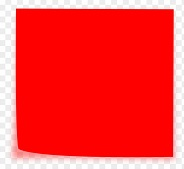

- = “I need help!”

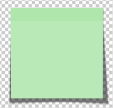

- = “Good to go!”
- No sticky = still working

# Lectures

- 30 minutes
- Highlighting concepts, resources, tools

# Schedule

### Today

- Functions part I
- Lunch
- Functions part II
- Documentation
- Version control using git, and github

### Tomorrow

- Objects and object oriented programming
- Functional programming
- R ecosystem and sharing your package
- Lunch
- Debugging
- Approaches to software development
- Testing

### Friday

- Designing an R package
- Playing nicely with others/being a good R citizen
- Releasing, promotion, and publications

# Friday afternoon

- Case studies and discussion

volunteers needed!